# S&P 500 Stock Market Predictions and Analyses

Francis Fynnwilliams & Keshav Nayyar

# Introduction

The S&P 500, a benchmark index comprising 500 of the largest publicly traded companies in the United States, serves as a crucial indicator of the overall health of the U.S. stock market and economy. In this project, we aim to leverage historical S&P 500 stock market data to predict future stock prices and analyze the performance of different sectors within the index. By employing advanced machine learning techniques, we seek to answer one primary question: "Can we accurately predict future stock prices based on historical data?" More on the S&P 500: https://www.investopedia.com/terms/s/sp500.asp

Answering this question holds significant importance for both investors and analysts. Accurate stock price predictions can inform investment strategies, helping individuals and institutions make more informed decisions and potentially increase their returns. By exploring this question, our project not only showcases the practical applications of data science in finance but also contributes valuable knowledge to the field of financial analytics.

# Necessary imports!

```python
#Imports!
import pandas as pd
import numpy as np
import matplotlib.pyplot as plt
import seaborn as sns
from scipy.stats import ttest_ind
from scipy.stats import f_oneway
import yfinance as yf
import scipy.stats as stats
from sklearn.model_selection import train_test_split
from sklearn.linear_model import LinearRegression
from sklearn.metrics import mean_squared_error
from sklearn.preprocessing import StandardScaler
import tensorflow as tf
```

# Data Curation

The dataset used in this project is sourced from Kaggle. (https://www.kaggle.com/datasets/camnugent/sandp500) It contains historical stock market data for various companies listed in the S&P 500 index over a five-year period. The data includes daily records of stock prices (open, high, low, close), trading volume, and the stock ticker symbol. This dataset provides a comprehensive view of the stock performance of companies within the S&P 500, making it suitable for analyzing trends, predicting future prices, and comparing sector performances. A large data set like this (619,000 rows) gives us the perfect playing field to do some machine learning! But first, we need to transform the data to meet our needs.

```python
url = "https://raw.githubusercontent.com/junaidc15/stocks_historic/main/all_stocks_5yr.csv"

stocks_data = pd.read_csv(url)

display(stocks_data)
```

|  | date | open | high | low | close | volume | Name |
| --- | --- | --- | --- | --- | --- | --- | --- |
| 0 | 2013-02-08 | 15.07 | 15.12 | 14.63 | 14.75 | 8407500 | AAL |
| 1 | 2013-02-11 | 14.89 | 15.01 | 14.26 | 14.46 | 8882000 | AAL |
| 2 | 2013-02-12 | 14.45 | 14.51 | 14.10 | 14.27 | 8126000 | AAL |
| 3 | 2013-02-13 | 14.30 | 14.94 | 14.25 | 14.66 | 10259500 | AAL |
| 4 | 2013-02-14 | 14.94 | 14.96 | 13.16 | 13.99 | 31879900 | AAL |
| ... | ... | ... | ... | ... | ... | ... | ... |
| 619035 | 2018-02-01 | 76.84 | 78.27 | 76.69 | 77.82 | 2982259 | ZTS |
| 619036 | 2018-02-02 | 77.53 | 78.12 | 76.73 | 76.78 | 2595187 | ZTS |
| 619037 | 2018-02-05 | 76.64 | 76.92 | 73.18 | 73.83 | 2962031 | ZTS |
| 619038 | 2018-02-06 | 72.74 | 74.56 | 72.13 | 73.27 | 4924323 | ZTS |
| 619039 | 2018-02-07 | 72.70 | 75.00 | 72.69 | 73.86 | 4534912 | ZTS |

619040 rows × 7 columns

- After loading in the data we wanted to know if there were any missing data points. Missing data points can alter our machine learning results and give inaccurate results. First, we checked for the amount of missing values per column to see if there were any missing data points. Then we dropped those rows that contained missing data points.

# Cleaning up the Data

```python
#Displaying the count of missing values for each column
missing_values = stocks_data.isnull().sum()
print("Before Cleaing")
print(missing_values)
print()

#Removing rows with missing values
cleaned_stocks_data = stocks_data.dropna()

#Verifying that no more missing values exist
cleaned_missing_values = cleaned_stocks_data.isnull().sum()
print("After Cleaning")
print(cleaned_missing_values)


print()
print("First 5 rows of the dataset")
print(cleaned_stocks_data.head())
```

```
Before Cleaing
date       0
open      11
high       8
low        8
close      0
volume     0
Name       0
dtype: int64

After Cleaning
date      0
open      0
high      0
low       0
close     0
volume    0
Name      0
dtype: int64

First 5 rows of the dataset
         date   open   high    low  close    volume Name
0  2013-02-08  15.07  15.12  14.63  14.75   8407500  AAL
1  2013-02-11  14.89  15.01  14.26  14.46   8882000  AAL
2  2013-02-12  14.45  14.51  14.10  14.27   8126000  AAL
3  2013-02-13  14.30  14.94  14.25  14.66  10259500  AAL
4  2013-02-14  14.94  14.96  13.16  13.99  31879900  AAL
```

- Next, we gathered all of the unique ticker symbols in the data set. The S&P 500 has a rigorous set of financial rules that determine if a company can be a part of the S&P 500 or not. This means that every year certain companies are added and taken out based on their performance. For our project, we only wanted to analyze companies that are currently in the S&P 500. The way that we were able to determine what company to remove was to look at the current 500 ticker symbols and cross-reference them with the 505 unique ticker symbols in our data set.

# Gathering all of the unique tickers

```python
def parse_stock_data(df):
    # Create a dictionary to store ticker data
    ticker_dict = {}

    # Get the unique tickers
    unique_tickers = df['Name'].unique()

    # Iterate through each unique ticker
    for ticker in unique_tickers:
        # Filter the DataFrame for the current ticker and convert to a list of dictionaries
        ticker_data = df[df['Name'] == ticker].to_dict(orient='records')
        ticker_dict[ticker] = ticker_data

    return ticker_dict

unique_tickers = parse_stock_data(cleaned_stocks_data)

# Print the number of unique tickers
print(f"Number of unique tickers: {len(unique_tickers)}")

# I'm just verifying the results here
for i, (ticker, data) in enumerate(unique_tickers.items()):
    if i >= 5:
        break
    print(f"\nTicker: {ticker}")
    print(f"Number of entries: {len(data)}")
    print(f"More Data: {data[0]}")
```

```
Number of unique tickers: 505

Ticker: AAL
Number of entries: 1259
More Data: {'date': '2013-02-08', 'open': 15.07, 'high': 15.12, 'low': 14.63, 'close': 14.75, 'volume': 8407500, 'Name': 'AAL'}

Ticker: AAPL
Number of entries: 1259
More Data: {'date': '2013-02-08', 'open': 67.7142, 'high': 68.4014, 'low': 66.8928, 'close': 67.8542, 'volume': 158168416, 'Name': 'AAPL'}

Ticker: AAP
Number of entries: 1259
More Data: {'date': '2013-02-08', 'open': 78.34, 'high': 79.72, 'low': 78.01, 'close': 78.9, 'volume': 1298137, 'Name': 'AAP'}

Ticker: ABBV
Number of entries: 1259
More Data: {'date': '2013-02-08', 'open': 36.37, 'high': 36.42, 'low': 35.825, 'close': 36.25, 'volume': 13858795, 'Name': 'ABBV'}

Ticker: ABC
Number of entries: 1259
More Data: {'date': '2013-02-08', 'open': 46.52, 'high': 46.895, 'low': 46.46, 'close': 46.89, 'volume': 1232802, 'Name': 'ABC'}
```

# Removing Tickers that are not currently on the S&P 500

```python
def remove_tickers(df, tickers_to_remove):
    # I created a boolean mask here where True means keep the row
    mask = ~cleaned_stocks_data['Name'].isin(tickers_to_remove)

    # Apply the mask to the DataFrame
    stocks_data_filtered = cleaned_stocks_data[mask]

    # Reset the index if needed
    stocks_data_filtered = stocks_data_filtered.reset_index(drop=True)

    return stocks_data_filtered

tickers_to_remove = ['ABC', 'ARNC', 'ATVI','DISH', 'RE']

stocks_data_without_tickers = remove_tickers(stocks_data, tickers_to_remove)

cleaned_stocks_data = stocks_data_without_tickers
```

# Split all of the ticker symbols into different Sectors

```python
sp500_data = pd.read_csv('/content/S&P 500 Companies (Standard and Poor 500) - basics.csv')

def categorize_sector(sector):
    sector = sector.lower()
    if 'information technology' == sector:
        return 'Technology'
    elif 'health care' == sector:
        return 'Healthcare'
    elif 'utilities' == sector:
        return 'Industrial'
    elif 'materials' == sector:
        return 'Industrial'
    elif 'telecommunications services' == sector:
        return 'Technology'
    elif 'energy' == sector:
        return 'Energy'
    elif 'industrials' == sector:
        return 'Industrial'
    elif 'financials' == sector:
        return 'Finance'
    elif 'consumer discretionary' == sector:
        return 'Consumer Discretionary'
    elif 'consumer staples' == sector:
        return 'Consumer Staples'
    elif 'real estate' == sector:
        return 'Finance'
    else:
        return 'Other'

# Apply the function to categorize sectors
sp500_data['Categorized Sector'] = sp500_data['Sector'].apply(categorize_sector)

# Merging the data
merged_data = cleaned_stocks_data.merge(sp500_data[['Symbol', 'Categorized Sector']], left_on='Name', right_on='Symbol', how='left')
merged_data.drop('Symbol', axis=1, inplace=True)

print("\nMerged Data Sample:")
print(merged_data.head())
```

```
Merged Data Sample:
         date   open   high    low  close    volume Name Categorized Sector
0  2013-02-08  15.07  15.12  14.63  14.75   8407500  AAL                NaN
1  2013-02-11  14.89  15.01  14.26  14.46   8882000  AAL                NaN
2  2013-02-12  14.45  14.51  14.10  14.27   8126000  AAL                NaN
3  2013-02-13  14.30  14.94  14.25  14.66  10259500  AAL                NaN
4  2013-02-14  14.94  14.96  13.16  13.99  31879900  AAL                NaN
```

# Exploratory Data Analysis

After cleaning the data and getting it ready for analysis we moved on to do some preliminary data analysis. This portion of the data analysis was mostly geared toward figuring out some large-scale statistics about the data set. What were the max and min values of all of the columns, the standard deviations, and the mean? This portion was really just for us to understand what the scale of the data set was and to look for any large variations in the data that might throw our primary analysis off course. More on statistical analysis: https://www.simplilearn.com/what-is-statistical-analysis-article

```python
#Descriptive Statistics
descriptive_stats = cleaned_stocks_data.describe()

#Feature Representation
unique_values = cleaned_stocks_data.nunique()

#Display the results
print("Detailed Statistics")
print(descriptive_stats)
print()
print("Unique Values")
print(unique_values)
```

```
Detailed Statistics
                open           high            low          close  \
count  612734.000000  612734.000000  612734.000000  612734.000000
mean       83.083573      83.839226      82.315964      83.103634
std        97.690509      98.522787      96.815719      97.700662
min         1.620000       1.690000       1.500000       1.590000
25%        40.290000      40.690000      39.905000      40.310000
50%        62.650000      63.210000      62.070000      62.670000
75%        94.380000      95.200000      93.550000      94.420000
max      2044.000000    2067.990000    2035.110000    2049.000000

             volume
count  6.127340e+05
mean   4.326900e+06
std    8.726257e+06
min    1.010000e+02
25%    1.070109e+06
50%    2.079222e+06
75%    4.270319e+06
max    6.182376e+08

Unique Values
date        1259
open       49654
high       81132
low        81949
close      51068
volume    580656
Name         500
dtype: int64
```

# **Descriptive Statistics**

**Mean Prices**: The average opening, high, low, and close prices are roughly similar, hovering around $83, indicating consistent trading ranges.

**Standard Deviation**: There is a high standard deviation in the price data, suggesting significant variability in stock prices, which could be due to stock volatility or differences across various stocks.

**Volume**: Trading volume shows a wide range, with a mean of about 4.32 million shares traded per day. The maximum trading volume recorded is extraordinarily high at over 618 million shares.

# **Feature Representation**

**Dates**: The dataset covers 1,259 unique dates.

**Stock Names (Tickers)**: There are 500 different stock tickers represented, implying the dataset spans a broad array of companies.

**Price Points**: The dataset contains a large number of unique open, high, low, and close values, indicating a detailed and comprehensive stock price record.

We also calculated the standard deviation of each individual stock, this would help us understand if a stock had low or high volatility.

```python
#Calculating standard deviation of closing prices for each stock
volatility = cleaned_stocks_data.groupby('Name')['close'].std().sort_values()
print(volatility)
```

```
Name
AES        1.487180
PBCT       1.648513
NWS        1.791033
WU         1.821214
F          1.957269
            ...
MTD      131.397220
GOOG     166.420529
GOOGL    187.573892
AMZN     282.500395
PCLN     320.533473
Name: close, Length: 500, dtype: float64
```

# High and Low volatility stocks

```python
#Displaying the five stocks with the highest and lowest volatility
high_volatility = volatility.nlargest(5)
low_volatility = volatility.nsmallest(5)

high_volatility, low_volatility
```

```
(Name
 PCLN     320.533473
 AMZN     282.500395
 GOOGL    187.573892
 GOOG     166.420529
 MTD      131.397220
 Name: close, dtype: float64,
 Name
 AES     1.487180
 PBCT    1.648513
 NWS     1.791033
 WU      1.821214
 F       1.957269
 Name: close, dtype: float64)
```

## Data Analysis through testing

Along with our preliminary data exploration we employed some testing techniques that would help us gather a greater understanding of the data set for our primary analysis.

# Chi-Square Test

The main focus of a chi-squared test is to to determine if a difference between observed data and expected data is due to chance, or if it is due to a relationship between the variables in our data. Our hypothesis for this test was "Is there a statistically significant association between the sectors and volatility?"

```python
np.random.seed(42)
cleaned_stocks_data = cleaned_stocks_data.copy()

cleaned_stocks_data['sector'] = np.random.choice(['Technology', 'Healthcare', 'Energy', 'Finance', 'Industrial', 'Consumer Staples', 'Consumer Discretionary'], size=len(cleaned_stocks_data))

# Calculating daily returns
cleaned_stocks_data['daily_return'] = cleaned_stocks_data.groupby('Name')['close'].pct_change()

# Calculating volatility and classifying
stock_volatility = cleaned_stocks_data.groupby('Name')['daily_return'].std()
volatility_labels = ['Low', 'Medium', 'High']
stock_volatility_class = pd.qcut(stock_volatility, 3, labels=volatility_labels, duplicates='drop').rename('volatility_class')

# Merging volatility classification back
cleaned_stocks_data = cleaned_stocks_data.merge(stock_volatility_class, left_on='Name', right_index=True, how='left')

# Creating a contingency table for the Chi-Square Test
contingency_table = pd.crosstab(cleaned_stocks_data['sector'], cleaned_stocks_data['volatility_class'])

# Performing Chi-Square Test
chi2, p, dof, expected = stats.chi2_contingency(contingency_table)

print("Chi-square statistic:", chi2)
print("P-value:", p)
```

```
Chi-square statistic: 20.508177192131697
P-value: 0.05806318194670076
```

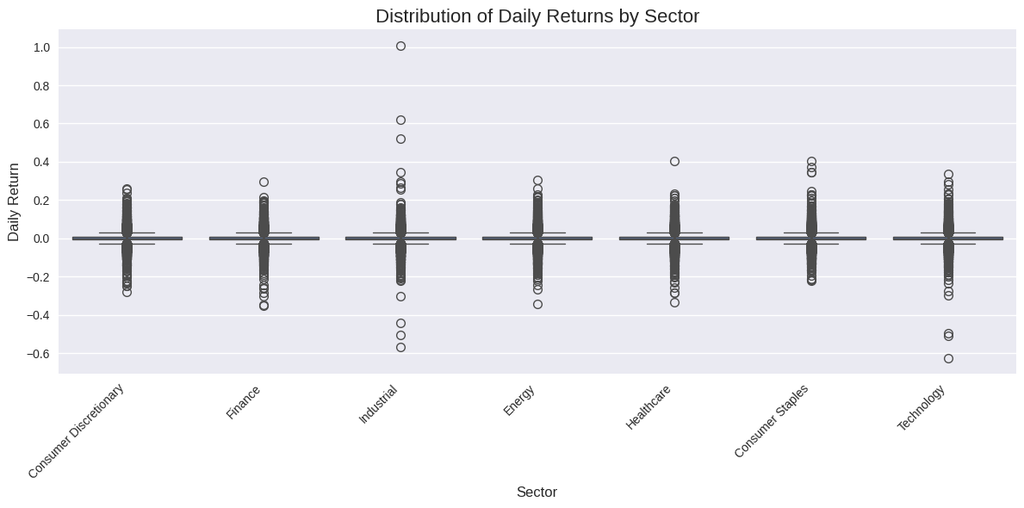

```python
plt.style.use('seaborn')


fig, ax = plt.subplots(figsize=(12, 6))


sns.boxplot(x='sector', y='daily_return', data=cleaned_stocks_data, ax=ax)


plt.title('Distribution of Daily Returns by Sector', fontsize=16)
plt.xlabel('Sector', fontsize=12)
plt.ylabel('Daily Return', fontsize=12)
plt.xticks(rotation=45, ha='right')

plt.tight_layout()


plt.show()
```

# Interpretation of Chi-Square Test Results

The Chi-Square Statistic is approximately 20.508. This value measures the difference between the observed frequencies in the contingency tables and the frequencies expected if sectors and volatility categories were independent.A higher value indicates a greater divergence from independence.

P-Value (0.05806): This p-value tests the null hypothesis that sector and volatility classification are independent of each other.

Since the p-value is greater than 0.05, it suggests that there is not enough evidence to reject the null hypothesis at the 5% significance level. Therefore, it is concluded that there is no statistically significant association between the sectors and volatility classes, although it's very close to the threshold.

# Z - Test

The Z-test is used to determine if there is a significant difference between the means of two groups or between a sample mean and a known population mean. The Z-value measures the number of standard deviations a data point is from the population mean, indicating the magnitude of the difference. The p-value indicates the probability that the observed difference occurred by chance; a low p-value (typically < 0.05) suggests that the difference is statistically significant.

```python
z_test_results = []

for sector in cleaned_stocks_data['sector'].unique():
    sector_data = cleaned_stocks_data[cleaned_stocks_data['sector'] == sector]

    # Further filter data for high and low volatility classes
    high_volatility = sector_data[sector_data['volatility_class'] == 'High']
    low_volatility = sector_data[sector_data['volatility_class'] == 'Low']

    # mean and standard deviation
    mean_h = high_volatility['daily_return'].mean()
    mean_l = low_volatility['daily_return'].mean()
    std_h = high_volatility['daily_return'].std()
    std_l = low_volatility['daily_return'].std()

    n_high = len(high_volatility['daily_return'].dropna())
    n_low = len(low_volatility['daily_return'].dropna())

    # Calculate the z-statistic
    p_std = np.sqrt((std_h**2 / n_high) + (std_l**2 / n_low))
    z_statistic = (mean_h - mean_l) / p_std

    # Calculate the p-value from the z-statistic
    p_value = 2 * stats.norm.sf(abs(z_statistic))

    z_test_results.append((sector, z_statistic, p_value))

z_test_df = pd.DataFrame(z_test_results, columns=['Sector', 'Z-Statistic', 'P-Value'])

display(z_test_df)
```

|  | Sector | Z-Statistic | P-Value |
| --- | --- | --- | --- |
| 0 | Consumer Discretionary | 2.746715 | 0.006020 |
| 1 | Finance | -0.886539 | 0.375327 |
| 2 | Industrial | -0.226402 | 0.820889 |
| 3 | Energy | 0.882831 | 0.377328 |
| 4 | Healthcare | -0.370419 | 0.711070 |
| 5 | Consumer Staples | 2.907144 | 0.003647 |
| 6 | Technology | -0.786593 | 0.431520 |

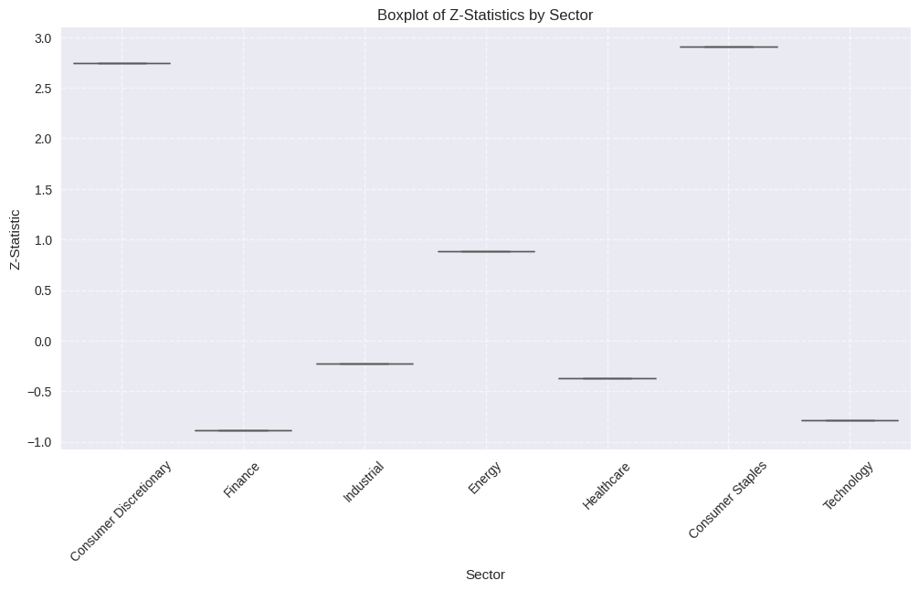

```python
plt.figure(figsize=(12, 6))
sns.boxplot(data=z_test_df, x='Sector', y='Z-Statistic', palette="coolwarm")
plt.title('Boxplot of Z-Statistics by Sector')
plt.xticks(rotation=45)  # Rotate sector names for better readability
plt.ylabel('Z-Statistic')
plt.xlabel('Sector')
plt.grid(True, linestyle='--', alpha=0.6)
plt.show()
```